# 6. 评测方法

Natural Language Processing I

6. 评测方法

WU Xiaokun 吴晓堃

xkun.wu [at] gmail

2022/03/18

# 评测：精确率，召回率，F度量

## 回顾：两类误差

**假阳 False positives** (Type I errors)

- 查出错误信息
- 提高准确度 accuracy、精度 precision

**假阴 False negatives** (Type II errors)

- 没有查出正确信息
- 提高覆盖率 coverage、召回率 recall

**评测**：模型的预测性能，即预测正确率

## 预测与标注

首先考虑只有两个类的情况，如正负面评价

- **预测值**只有两种可能性：`+`, `-`
- **标注**也只有两种可能性：`T`, `F`

评测时需要将预测与标注**两两组合**进行对比

- 假阳：错误的阳性；预测是`+`，但实际是`F`
- 假阴：错误的阴性；预测是`-`，但实际是`T`

## 混淆矩阵

**混淆 confusion 矩阵**：预测与标注对比的可视化

|  | **T** | **F** |  |
| --- | --- | --- | --- |
| **P** | True Positive (TP) | False Positive (FP) |  |
| **N** | False Negative (FN) | True Negative (TN) |  |

- 两种正确的预测
  - TP：正确的阳性
  - TN：正确的阴性

评测：计算预测的正确率

- 一定与**正确的预测**（TP和TN）有关

## 准确度

**准确度 accuracy**：正确的预测所占百分比

|  | **T** | **F** |  |
| --- | --- | --- | --- |
| **P** | TP | FP |  |
| **N** | FN | TN |  |
|  |  |  | $A = \frac{TP+TN}{TP+FP+TN+FN}$ |

看起来像是很自然的度量

- 问题：当**类间数据不平衡**时会失效

## 不平衡的网页检索

假设网页检索返回$1\cdot 10^{6}$条信息

构造一个假的分类器：对任何输入都输出“不相关”

- 准确度：$A = \frac{TP+TN}{TP+FP+TN+FN} = 99.99\%$

目标是发现**罕见情况**时，越罕见问题就越严重

- 例如：对罕见病检测都预测阴性

推论：**TP要更重要一些**，而TN会带来大量干扰信息

## 精确度、召回率

**精确度 precision**：预测为`+`的结果中，正确（实际确实是）的百分比

**召回率 recall**：标注为`T`的数据中，正确检测出来（预测阳性）的百分比

|  | **T** | **F** |  |
| --- | --- | --- | --- |
| **P** | TP | FP | $P = \frac{TP}{TP+FP}$ |
| **N** | FN | TN |  |
|  | $R = \frac{TP}{TP+FN}$ |  |  |

注意：两者都只关注TP，而**把容易带来干扰的TN排除**了

- 例如医疗检测中的TN就是健康人

前面例子：$R = \frac{TP}{TP+FN} = \frac{0}{100} = 0\%$

## 分类问题应用

精确度高：阳性**置信度**高；召回率高：阳性**辨识力**强。

- 如何确定辨识力？选取**阈值**

例如分类真值：$[T, F, F]$；预测值：$[0.7, 0.3, 0.5]$

- 阈值$0.5$：$P = \frac{TP}{TP+FP} = 1/2$；$R = \frac{TP}{TP+FN} = 1$

## Precision-Recall Curve

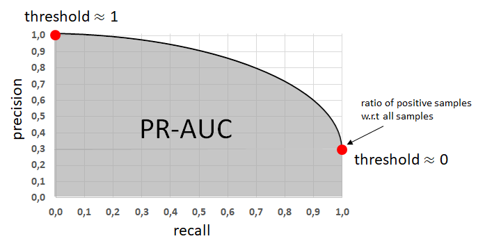

- 阈值$0$：所有真值都检出；阈值接近$1$：所有真值都正确
  - 曲线越向右上角越好

**Area Under Curve (AUC)**：面积越大越好

## 准确度、精确度

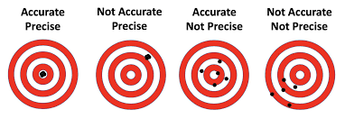

- TP：靶心附近；FP：偏离靶心

|  | **T** | **F** |  |
| --- | --- | --- | --- |
| **P** | TP | FP | $P = \frac{TP}{TP+FP}$ |
| **N** | FN | TN |  |
|  |  |  | $A = \frac{TP+TN}{TP+FP+TN+FN}$ |

## 单一度量

实际应用通常希望将两种度量（精确度、召回率）综合考虑

- 最常用的是加权**调和平均 harmonic mean**

$$\begin{aligned}
F_\alpha &= \frac{1}{\alpha \frac{1}{P} + (1-\alpha) \frac{1}{R}}\\
\end{aligned}$$

- 调和平均是**保守 conservative 度量**：（相比算数平均）较低的值权重更高

常用变换形式：$\beta^2 = \frac{1}{\alpha} -1 \Rightarrow \beta^2 +1 = \frac{1}{\alpha}$

- $\beta$的定义可以保证$\frac{1}{\alpha} -1$非负

$$\begin{aligned}
F_\alpha &= \frac{\frac{1}{\alpha}}{\frac{1}{P} + (\frac{1}{\alpha} -1) \frac{1}{R}} = \frac{\beta^2 +1}{\frac{1}{P} + \beta^2 \frac{1}{R}}\\
\end{aligned}$$

## F度量

**F度量 F-measure**：精确度、召回率的加权调和平均

$$\begin{aligned}
F_\alpha &= \frac{1}{\alpha \frac{1}{P} + (1-\alpha) \frac{1}{R}} = \frac{\beta^2 +1}{\frac{1}{P} + \beta^2 \frac{1}{R}}\\
F_\beta &= \frac{(\beta^2 + 1) PR}{\beta^2 P + R}\\
\end{aligned}$$

- $\beta > 1$：强调召回率；$\beta < 1$：强调精确度

最常用的是**$F_1$度量**：$\beta = 1$

$$\begin{aligned}
F_1 &= \frac{2 PR}{P + R}\\
\end{aligned}$$

## Average Precision (AP)

精确度的加权和；权重：召回率增量

$$AP = \sum_{k=0}^{n-1} [R(k) - R(k+1)] * P(k)$$

- $R(n) = 0, P(n) = 1$

Mean Average Precision (mAP)：多类AP均值

$$AP = \frac{1}{n} \sum_{k=1}^n AP_k$$